# Assignment 6

### Question 3: What is the Mobile Food Truck availability throughout the different days in the week? Where in the city are the food trucks located during the week and where are they located during the weekend?

```python
#Get a dataframe with each cater's coordinates for each day of the week.
Location_food_truck = pd.read_sql("SELECT DISTINCT permit.Applicant, location.Address, location.Latitude, location.Longitude , schedule.DayOfWeek \
                             FROM mobile_food_locations location \
                             INNER JOIN mobile_food_schedule schedule ON location.locationid = schedule.locationid \
                             INNER JOIN mobile_food_permits permit ON schedule.permit = permit.permit \
                             WHERE permit.Status=='APPROVED'", db)
Location_food_truck.head()
```

|  | Applicant | Address | Latitude | Longitude | DayOfWeek |
| --- | --- | --- | --- | --- | --- |
| 0 | F & C Catering | 2890 03RD ST | 37.753109 | -122.38817 | Fr |
| 1 | F & C Catering | 2890 03RD ST | 37.753109 | -122.38817 | Mo |
| 2 | F & C Catering | 2890 03RD ST | 37.753109 | -122.38817 | Th |
| 3 | F & C Catering | 2890 03RD ST | 37.753109 | -122.38817 | Tu |
| 4 | F & C Catering | 2890 03RD ST | 37.753109 | -122.38817 | We |

```python
#Get the counts for foodtrucks based on the different days of the week
food_truck_days = pd.DataFrame(Location_food_truck.DayOfWeek.value_counts())
food_truck_days
```

|  | DayOfWeek |
| --- | --- |
| We | 135 |
| Fr | 134 |
| Mo | 133 |
| Th | 132 |
| Tu | 131 |
| Sa | 34 |
| Su | 32 |

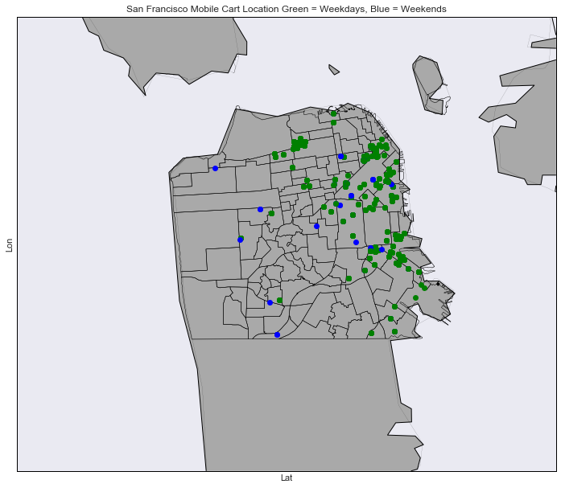

```python
# INITIALIZE BASEMAP
map_sf = Basemap(projection="merc", llcrnrlon=-122.6, llcrnrlat=37.65, urcrnrlon=-122.3, urcrnrlat=37.85, resolution="h", area_thresh = 0.1)

# DRAW IN LINES AND SHAPEFILE
map_sf.drawcoastlines()
map_sf.drawmapboundary()
map_sf.drawcounties()
map_sf.readshapefile("/Users/Ricky/Desktop/SF Find Neighborhoods/geo_export_36d997db-6315-47c9-b61a-53934fce39c3", "geo_export_36d997db-6315-47c9-b61a-53934fce39c3")
map_sf.fillcontinents(color="darkgrey")

for lon, lat, dow in zip(Location_food_truck.Longitude, Location_food_truck.Latitude, Location_food_truck.DayOfWeek):
    x, y = map_sf(lon, lat)

    # Weekday
    color = "g"
    markersize = 5
    alpha = 0.6

    # Weekend
    if dow == "Sa":
        color = "b"
        markersize = 10
        alpha = .9
    if dow == "Su":
        color = "b"
        markersize = 10
        alpha = .9

    map_sf.plot(x, y, color + "o", markersize, alpha)

plt.title("San Francisco Mobile Cart Location Green = Weekdays, Blue = Weekends")
plt.xlabel("Lat")
plt.ylabel("Lon")
plt.show()
```

Since I will be working in San Francisco's financial district in the fall I was curious about the availability of food trucks, as well as the difference in availability between the weekdays and the weekends. To examine this question I first I wanted to get a count for the food truck availability based on the different day of the week. Outside of a couple food trucks, the resultant counts were almost identical based on whether the day was a weekday or a weekend. There are almost four times as many food trucks on weekdays as there are on weekends.

Getting these facts I wanted to see the location of these food trucks by day. In the map plot above I plotted the lcoations of the food trucks where green equates to weekdays and blue equates to weekends. There is an obvious difference between the location of these food trucks based on the day. On weekdays the foodtrucks are focused in the business districts of San Francisco where they can service the lunch time rush of the business day. Once weekends come around the food trucks either don't operate or move to a wider breath of locations that are typical more residential. This is because no one is working during the weekends and so the food trucks try to station themselves to be closer to where people live, rather than were they work.

### Question 4: Where are high schools and community colleges located in SF? Are the type of schools affected by the median household income?

```python
schools = pd.read_sql("SELECT Name, Entity, Category, Lat, Lon FROM schools \
            WHERE LowerGrade >= 9", db)
schools.head()
```

|  | Name | Entity | Category | Lat | Lon |
| --- | --- | --- | --- | --- | --- |
| 0 | Asawa, Ruth Asawa San Francisco School Of The ... | SFUSD | USD Grades 9-12 | 37.745316 | -122.448830 |
| 1 | Balboa High School | SFUSD | USD Grades 9-12 | 37.721142 | -122.441399 |
| 2 | Burton, Phillip And Sala Burton High School | SFUSD | USD Grades 9-12 | 37.721546 | -122.406555 |
| 3 | City Arts And Tech High School | SFUSD | USD Grades 9-12 | 37.718784 | -122.424667 |
| 4 | Downtown High School | SFUSD | USD Grades 9-12 | 37.761398 | -122.403702 |

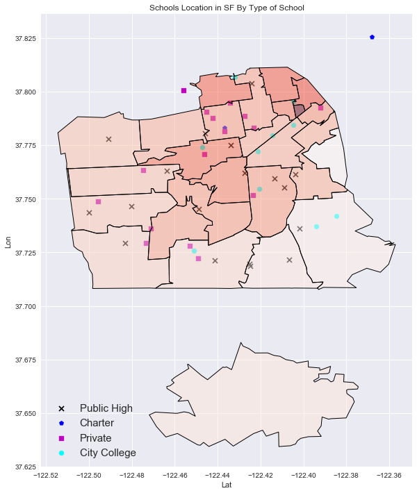

```python
#Plot the schools on the base map.
schools_plot = df_merged.plot(column='Median Price Per Sq ft', colormap="Reds")
public_high = schools.loc[schools["Category"] == "USD Grades 9-12"]
charter = schools.loc[schools["Category"] == "USD Charter School"]
private = schools.loc[schools["Category"] == "Independent / Private"]
city_college = schools.loc[schools["Category"] == "Community College District"]

#Plot the scatter points
pub_highschool = plt.scatter(public_high["Lon"], public_high["Lat"], marker='x', color = 'black')
chart = plt.scatter(charter["Lon"], charter["Lat"],marker='p', color = 'blue')
priv = plt.scatter(private["Lon"], private["Lat"], marker='s', color = 'm')
city = plt.scatter(city_college["Lon"], city_college["Lat"], color = 'cyan')

#Add plot components
plt.title("Schools Location in SF By Type of School")
plt.xlabel("Lat")
plt.ylabel("Lon")
plt.legend((pub_highschool, chart, priv, city),
           ('Public High', 'Charter', 'Private', 'City College'),
           scatterpoints=1,
           loc='lower left',
           fontsize=15)
plt.show()
```

### Question 5: On average how much bigger are parking garrages than parking lots? Are garages and parking lots distributed differently in SF?

```python
#Get the dataframe for average garage and lot size.
parking_size = pd.read_sql("SELECT Distinct Owner, GarOrLot, RegCap, Lat, Lon from parking \
                    Where GarOrLot == 'G' or GarOrLot == 'L' \
                    GROUP BY GarOrLot", db)
```

```python
#Find the difference between parking lots and garages.
Lot_bigger_than_Garages = parking_size["RegCap"][1]-parking_size["RegCap"][0]

#Find how many times bigger parking lots are than garages.
Lot_bigger_than_Garages_times = parking_size["RegCap"][1]/float(parking_size["RegCap"][0])
print "Lots are bigger than garages by", Lot_bigger_than_garage, "cars on average."
print "Lots are on average", Lot_bigger_than_Garages_times,"times bigger than garages."
```

[output not shown]

```python
#Create the parking database based on garages and lots to get the individual longitude and latitudes.
parking = pd.read_sql("SELECT Distinct Owner, GarOrLot, RegCap, Lat, Lon from parking \
                    Where GarOrLot == 'G' or GarOrLot == 'L'", db)
```

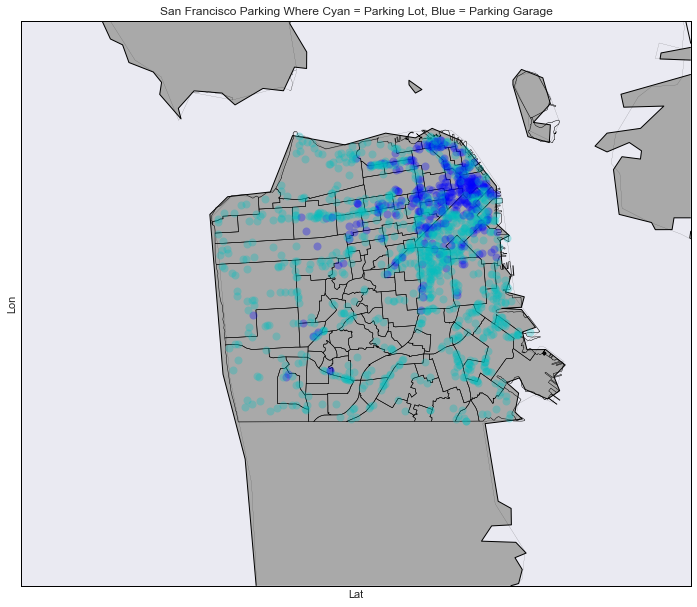

```python
# Draw the basemap
map_sf = Basemap(projection="merc", llcrnrlon=-122.6, llcrnrlat=37.65, urcrnrlon=-122.3, urcrnrlat=37.85, resolution="h", area_thresh = 0.1)
map_sf.drawcoastlines()
map_sf.drawmapboundary()
map_sf.drawcounties()
map_sf.readshapefile("/Users/Ricky/Desktop/SF Find Neighborhoods/geo_export_36d997db-6315-47c9-b61a-53934fce39c3", "geo_export_36d997db-6315-47c9-b61a-53934fce39c3")
map_sf.fillcontinents(color="darkgrey")

for lon, lat, GarOrLot in zip(parking.Lon, parking.Lat, parking.GarOrLot):
    x, y = map_sf(lon, lat)

    # Parking Lot
    color = "c"

    # Parking Garage
    if GarOrLot == "G":
        color = "b"

    map_sf.plot(x, y, color + "o", markersize = 8, alpha=.3)

plt.title("San Francisco Parking Where Cyan = Parking Lot, Blue = Parking Garage")
plt.xlabel("Lat")
plt.ylabel("Lon")
plt.show()
```

```python
db.close()
```